# FARMR!SK automatic report

The main pathways of disease entry are: **Neigbouring farms** and **Vehicle visits to the farm**.

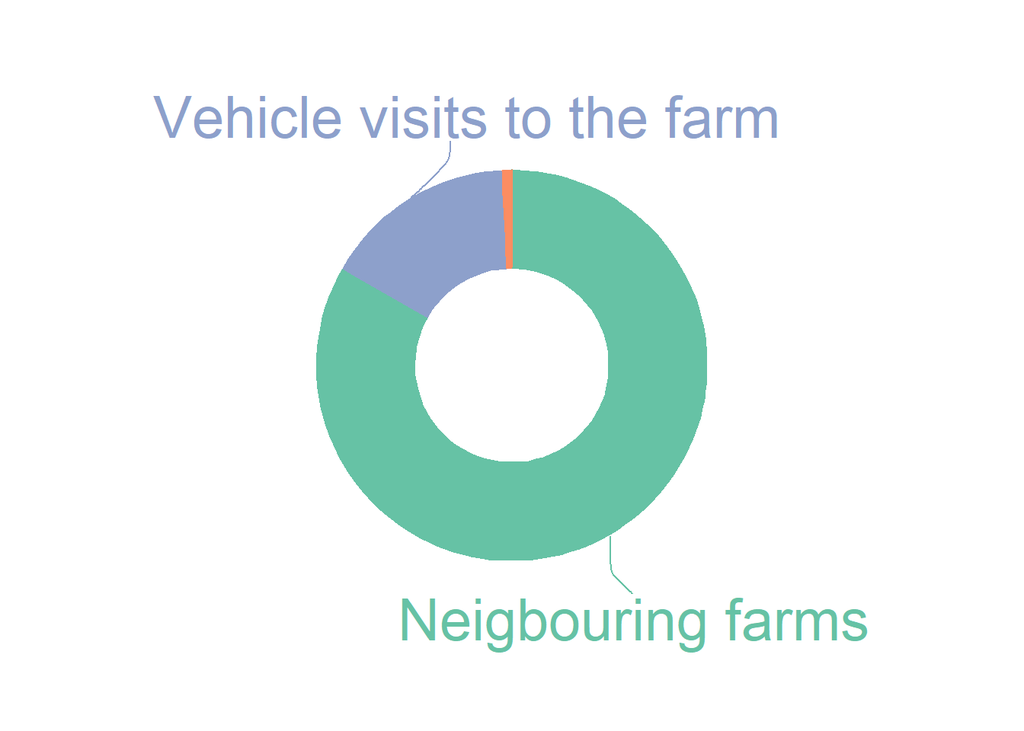

(a) IBR

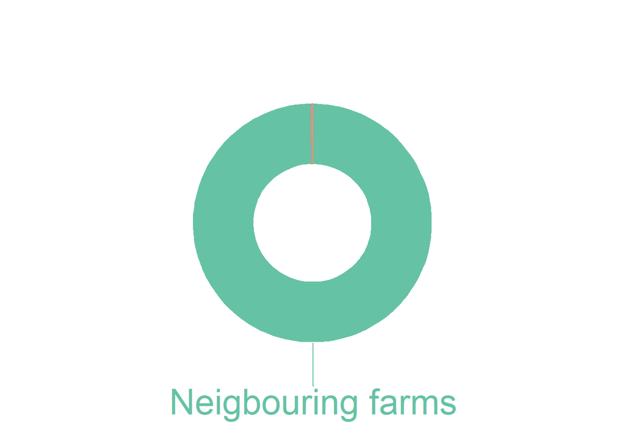

(b) BVD

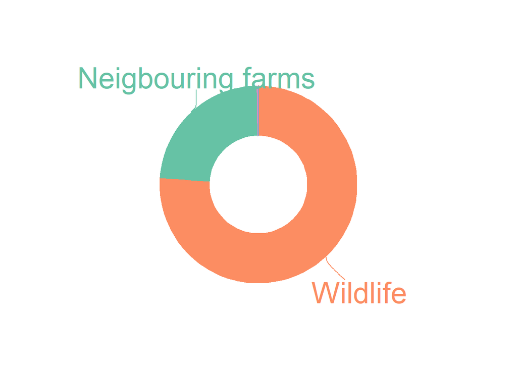

(c) TB

Figure 1.2: Risk of disease entry by pathway

## **Infectious Bovine Rhinotracheitis (IBR)**

### Current risk

Annual risk of IBR entry in the farm: **0.925%** (0.691-1.2%)

By pathway:

- Neigbouring farms: **0.762%** (0.562-0.989%)
- Vehicle visits to the farm: **0.146%** (0.0456-0.312%)
- People visits to the farm: **0.00722%** (0.00254-0.0144%)

### Risk reduction of biosecurity measures

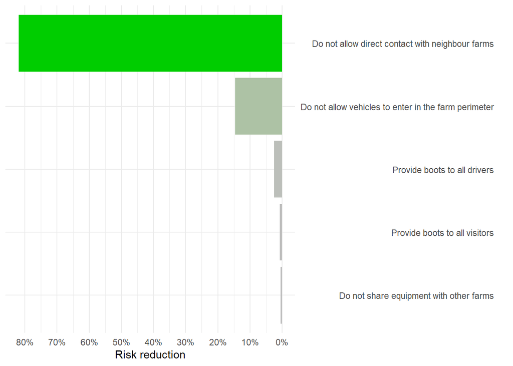

## **Bovine viral diarrhea (BVD)**

### Current risk

Annual risk of BVD entry in the farm: **28.5%** (21.7-33.1%)

By pathway:

- Neigbouring farms: **28.4%** (21.7-33%)
- Vehicle visits to the farm: **0.0333%** (0.00855-0.0758%)
- People visits to the farm: **0.028%** (0.00756-0.067%)

### Risk reduction of biosecurity measures

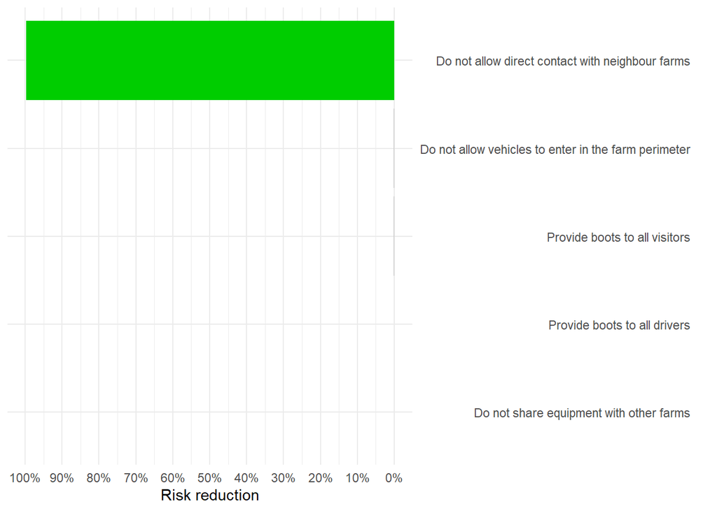

## **Bovine Tuberculosis (TB)**

### Current risk

Annual risk of TB entry in the farm: **0.0472%** (0.02-0.107%)

By pathway:

- Wildlife: **0.0346%** (0.00991-0.092%)
- Neigbouring farms: **0.0108%** (0.00613-0.0212%)
- Vehicle visits to the farm: **8.53e-05%** (3.73e-06-0.000631%)
- People visits to the farm: **9.1e-06%** (4.75e-07-4.1e-05%)

### Risk reduction of biosecurity measures

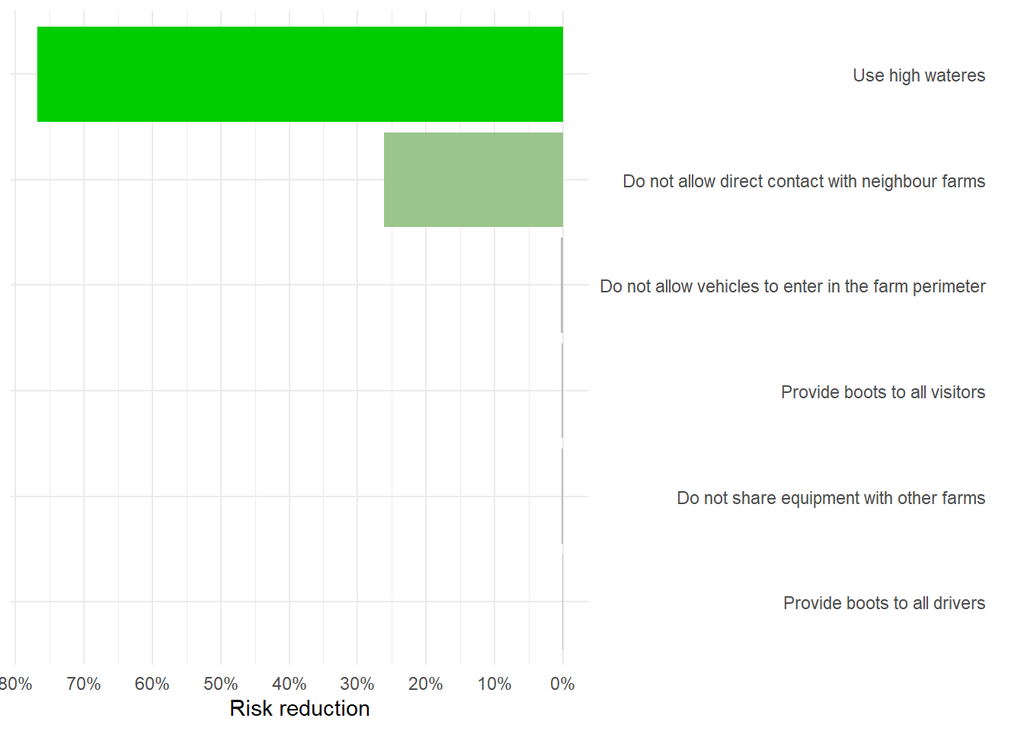

# 🐄 Description of the farm

## Farm information

**Location:** Cataluña, Spain

**Farm type:** Beef cattle, NA

**Cattle cens:**

- 113 Calves ( <8 m)
- 60 Heifers (8 - 24 m)
- 140 Adult cows (>24 m)
- 6 Bulls

**Other animals in the farm:**

- **Direct contact with cattle:** 3 dogs, 7 cats
- **No direct contact with cattle:** 2 horses

**Neighbours**: 3 cattle farms within a 1-2km radious, possible direct contact (IBR: 0.762%, BVD: 28.4%, TB: 0.0108%)

## Farm vehicles

| veh_id | Size | Shared | Cleaning |
| --- | --- | --- | --- |
| Camionet propi (a) | 20m2 | No | Each time it is used |
| Remolquet gris (c) | 10m2 | No | Each time it is used |

## Visits

### People entering the barn

| Visit | Type | Frequency | Boots | Equipment | Risk |
| --- | --- | --- | --- | --- | --- |
| Veterinari (J.Padrós) | External veterinarians | 6 | Always used in other farms, unk cleaned and disinfected | Always used in other farms, unk cleaned and disinfected | IBR: 0.00722%, BVD: 0.028%, TB: 9.1e-06% |
| Control de plagues | Other professionals (e.g. electrician, plumber…) | 120 | Never used in other farms | Never used in other farms | negligible risk |

### Vehicles entering the farm perimeter

| Visit | Type | Frequency | Driver | Risk |
| --- | --- | --- | --- | --- |
| Escorxador vaques | Slaughterhouse vehicle | 2 | Enters areas used by farm animals (no contact with animals), boots always used in other farms, unk cleaned and disinfected | IBR: 0.0674%, BVD: 0.0158%, TB: 4.47e-05% |
| Escorxador vedells | Slaughterhouse vehicle | 14 | No contact with animals | IBR: 0.0309%, BVD: 0.00567%, TB: 1.99e-06% |
| Concentrat i gra | Feed vehicle | 104 | - | IBR: 0.0259%, BVD: 0.00477%, TB: 1.72e-06% |
| Camionet propi | Adult cattle transport vehicle (own and not shared) | 24 | - | IBR: 0%, BVD: 0%, TB: 0% |

# 🚚 Movements

Animal movements in the last 12 months

*No movements in selected period*

### Health status and tests in origin

### Quarantine

#### Characteristics

*No quarantine*

# 🐗 Wildlife

**Wildlife:** IBR: -, BVD: -, TB: 0.0346%

- Outdoors grazing: Outdoors grazing, complete perimeter fence, wildlife can access the farm (electric) (IBR: -, BVD: -, TB: 0.0346%)
- Pasture (trashumance): No pastures

### Farm water points

| Risk point | Mud/Organic | Risk |
| --- | --- | --- |
| 100% Low waterer (<90cm) | 0% | 0.0% (0.0-0.0%) |
| 100% Waterhole | 100% | 0.014% (0.0016-0.062%) |
| 100% River | 100% | 0.0024% (3e-04-0.011%) |
| 100% feed | 100% | 0.014% (0.0017-0.059%) |

### Pasture water points

*No pasture water points*

# Comments

*No survey comments*

# Technical Annex

- Simulation date: 2025-11-26 13:01:56
- Script unification date: 2025-11-26 13:00:57
- Repository: https://github.com/NataliaCiria/biosecurity_model.git
- Last commit: 6f6c5082bb8fc7867ae78292acd565f0f43839f1
- Last commit date: 2025-11-18 14:53:11
- user_id:
- farm_id: bc6_v1
- Risk timeframe: 360 days
- Calculate all summaries: FALSE
- Automatic what-if scenarios: TRUE
- Analyse model sensitivity: FALSE
- Farm biosecurity survey: _v4_2_mod_ciria 2015-03-10
- No movements